# 20192208 Journal Week 1

Noud Klaassen

22-8-2019

I Downloaded the VCF-files from the K562-paper (non-phased) and read them into an R table. Comment.char makes sure that the rows that start with an # will be removed

```r
K562_IndelSNV_NF <- read.table("~/projects/SuRE_K562/data/external/Encode_K562_VCF/ENCFF606RIC.vcf.gz", comment.char = "#",)
colnames(K562_IndelSNV_NF) <- c("CHROM", "POS", "ID", "REF", "ALT", "QUAL", "FILTER", 'INFO', 'FORMAT', 'K562_PE')
```

Next, I generated a histogram displaying the distribution plot of the QUAL scores of the different variants that were called (including SNVs and Indels)

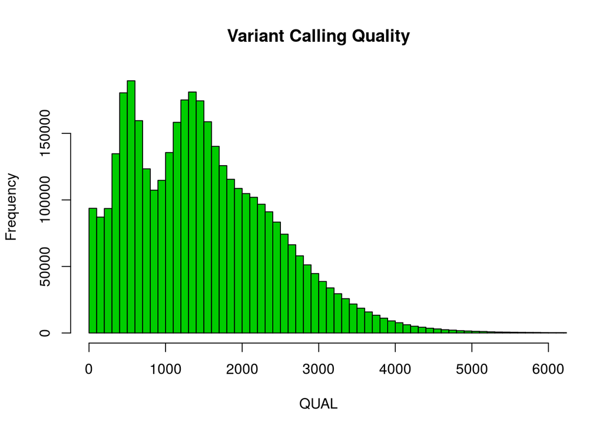

```r
hist(K562_IndelSNV_NF[,6], col = 3, xlab = "QUAL", xlim = c(0, 6000),breaks = 1000, main = "Variant Calling Quality")
```

Then, I wanted to count the number of variants (SNVs and Indels) per chromosome, by using a loop. In this loop, the number of rows will be counted for each specific chromosome. I use the paste-function to generate the required character to search for right chromosome (e.g. chr4). The X-chromosome requires a conversion from the number 23 to the character ‘X’. The nrow-function wil count the number of rows that have been generated for a certain chromosome. Thes counts are stored in the Count-variable.

```r
Count = c()
for (i in 1:23) {
  if (i == 23) {i <- c("X")}
        Chr_i = paste("chr", i, sep="")
        Chr_i_list <- K562_IndelSNV_NF[which(K562_IndelSNV_NF$CHROM == Chr_i),]
        MNV_Count <- nrow(Chr_i_list)
  if (i == "X") {i <- 23}
        Count[i] <- MNV_Count
}
```

These values can then be plotted in a bar-graph

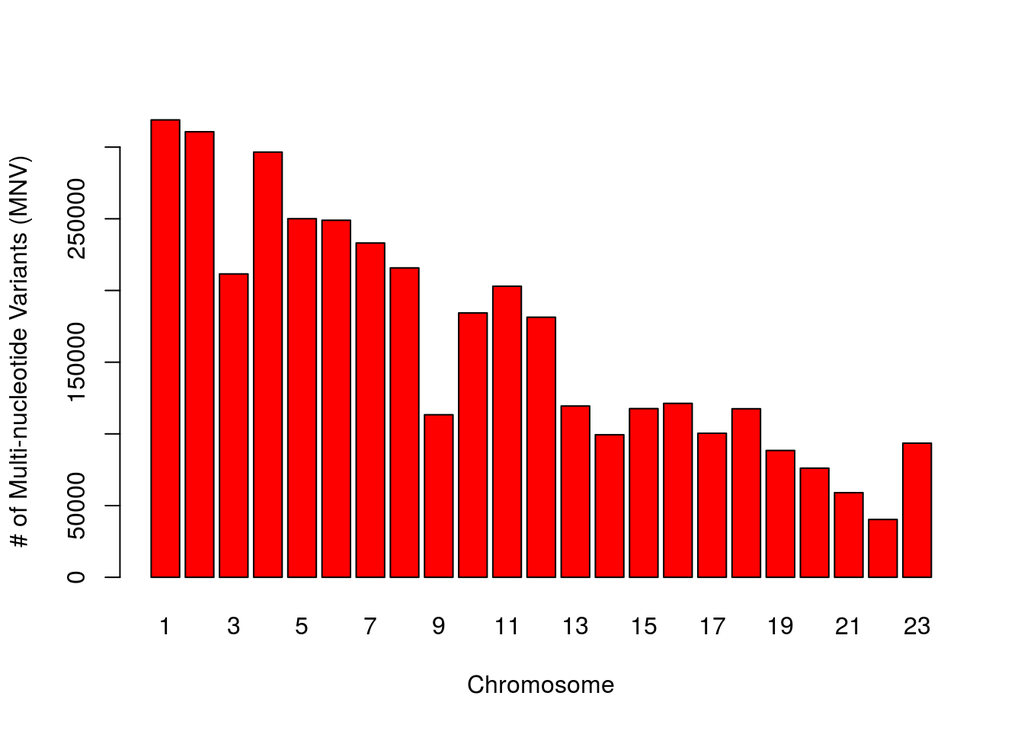

```r
barplot(Count,space = 0.2,names.arg = c(1:23), col = 2, xlab = "Chromosome", ylab = "# of Multi-nucleotide Variants (MNV)")
```

In the next step I wanted to separate the SNVs from the Indels. To do that i needed to transform the ALT and REF columns from factors to characters, so the length of the characters could be determined by nchar-function. In this way, only the variations that have 1 nt in their REF-sequence and 1-nt in the ALT sequence will be kept.

```r
Nt_REF <- nchar(as.character(K562_IndelSNV_NF[,4])) #Count nr. of characters of REF in a vector
SNV_REF_Only <- K562_IndelSNV_NF[which(Nt_REF == 1),] #Filter in the database for REF==1
Nt_ALT <- nchar(as.character(SNV_REF_Only[,5])) #Count in the new database nr of characters in ALT
SNV_list <- SNV_REF_Only[which(Nt_ALT == 1),]
```

```r
SNP_list <- SNV_list[which(nchar(as.character(SNV_list[,3])) == 1),]
```